# Rockborne Week 6 Python EDA

- Introduction
  - Data Dictionary
- Section 1: Overall Distributions
  - Figure 1.1: Crime Count Distribution
  - Figure 1.2: Crime Types Distribution
  - Figure 1.3: Crime Outcomes Distribution
  - Figure 1.4: Burglary Crimes Outcomes
- Section 2: Comparisons Between Regions
  - Figure 2.1: Crime Types By Region
  - Figure 2.2: Crime Relative Location by Region
  - Figure 2.3: Highest Crime LSOAs by Region
- Section 3: Crime Maps
  - Figure 3.1: Highest Crime LSOAs Map
  - Figure 3.2: West Midlands LSOAs Crime Map
  - Figure 3.3: All Crime Cluster Map
  - Figure 3.4: Cluster Map Use Case Example
- Section 4: Time Series Data
  - Figure 4.1: Crime Count Over Time (Monthly)
  - Figure 4.2: Crime Count Over Time (Smoothed)
- Conclusions and Next Steps

## Introduction

This project places us in the role of a data analyst within a real estate company. We have been assigned to generate an analysis on crime in the UK. Our stakeholder is Nadine Green, Head of Sales. Nadine is keen to know which locations are most / least desirable and any useful information for her to make informed decisions around sales.

Nadine Green has requested this analysis to have a general idea of the crime across the regions. The outcome of this should be the selection of two police forces for further study (to do in a later stage).

### Data Dictionary

| Column Name | Data Type | Description | Example |
| --- | --- | --- | --- |
| **Crime ID** | String | Unique identifier assigned to each recorded crime incident. | `a1b2c3d4` |
| **Month** | Date (YYYY-MM) | The month when the crime was recorded by the police force. | `2024-01` |
| **Reported by** | Categorical (String) | The police force that recorded the crime incident. | `West Midlands Police` |
| **Falls within** | Categorical (String) | The police jurisdiction responsible for the geographic area where the crime occurred. | `Thames Valley Police` |
| **Longitude** | Float | Longitude coordinate of the crime location in decimal degrees (WGS84). | `-1.2577` |
| **Latitude** | Float | Latitude coordinate of the crime location in decimal degrees (WGS84). | `52.4068` |
| **Location** | String | Approximate location of the crime, typically anonymised to protect privacy. | `On or near High Street` |
| **LSOA code** | String | Code identifying the **Lower Layer Super Output Area (LSOA)** where the crime occurred. Used for small-area statistical analysis. | `E01012345` |
| **LSOA name** | String | Human-readable name of the LSOA corresponding to the code. | `Oxford 012B` |
| **Crime type** | Categorical (String) | Classification of the crime (e.g., burglary, vehicle crime, anti-social behaviour). | `Burglary` |
| **Last outcome category** | Categorical (String) | Final recorded outcome of the investigation for the crime incident. | `Under investigation` |

Notes: LSOAs are small geographic areas used for statistical analysis in England and Wales. Each LSOA typically contains ~1,500 residents.

## Section 1: Overall Distributions

### Figure 1.1: Crime Count Distribution

The below chart illustrates the total number of crimes in each region over the 25 months of the dataset. Note that West Midlands Police, and West Yorkshire Police have very similar crime count which could be useful for making comparisons.

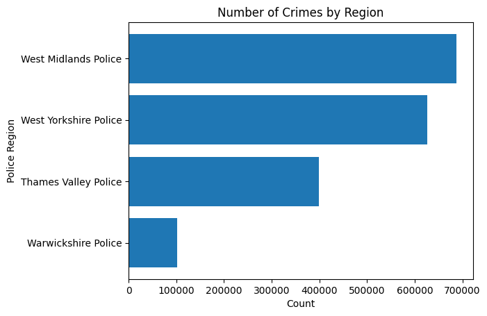

### Figure 1.2: Crime Types Distribution

The below chart illustrates the category which crimes fall under of which there are 14. A large proportion of crimes are listed under violence and sexual offences.

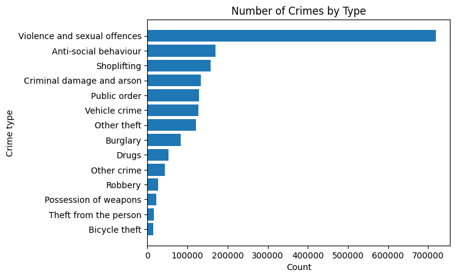

### Figure 1.3: Crime Outcomes Distribution

The below graph shows the possible outcomes of a crime and count of crimes that fall under a given category. Here, the vast majority of crimes resulted in either "Unable to prosecute suspect" or "Investigation complete; no suspect identified" which suggests that most crimes tend to have unfavourable outcomes.

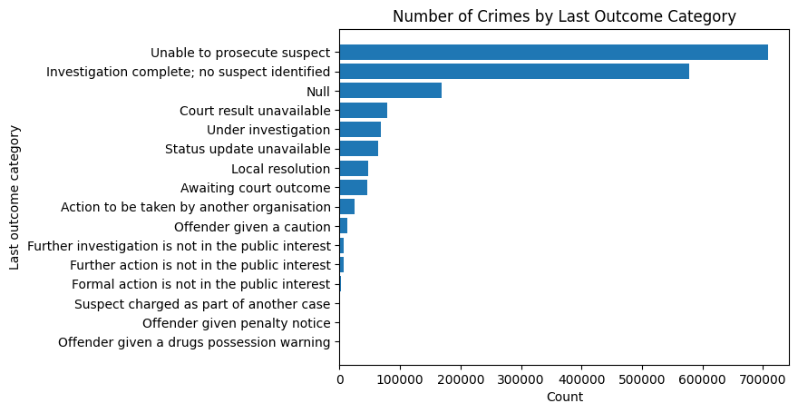

### Figure 1.4: Burglary Crimes Outcomes

The below chart shows the outcomes of crimes classed under burglary. Note that the majority of cases result in "Investigation complete; no suspect identified".

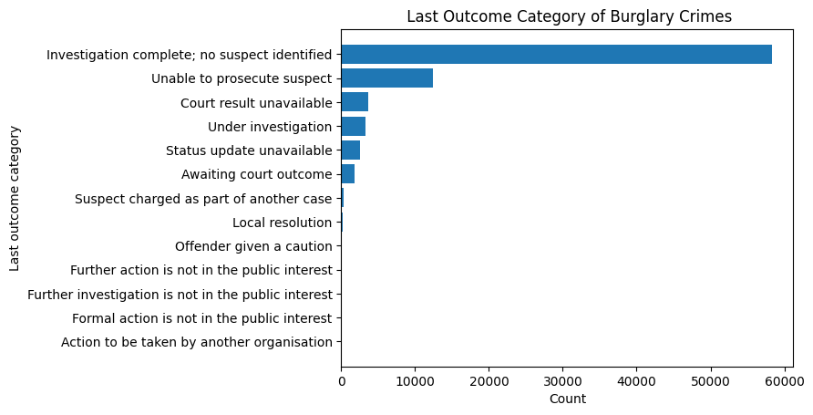

## Section 2: Comparisons Between Regions

The graphs in this section will be in a two by two grid to make comparisons between different police regions. The axis scales are non consistent as the aim is to show distribution while keeping crime count information

### Figure 2.1: Crime Types By Region

The below facets rank the most common crime types by police region. While "Violence and sexual offences" ranks the highest for all regions. Anti-social behaviour is ranked comparitively low for the West Midlands compared to other regions. Anti-social behaviour also makes up a larger proportion of crimes in the Warwickshire region compared to others.

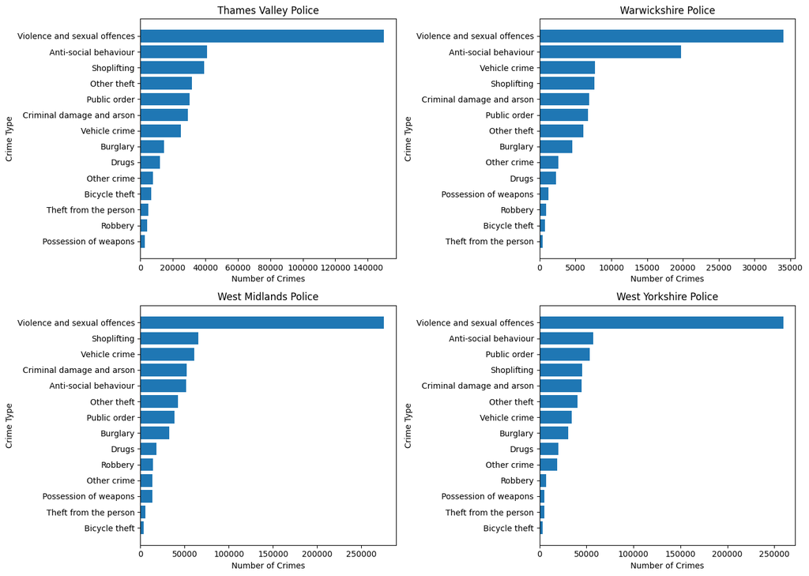

### Figure 2.2: Crime Relative Location by Region

The below facets show the most common relative position of crime for each region. Some of these relative positions are generic such as "On or near Supermarket" while others are location specific such as "On or near Warwick Street". Here, it is noted that "Parking Area", "Supermarket", "Shopping Area", and "Petrol Station" are in the top four most common relative locations for all police regions, suggesting that locations near these landmarks may possibly experience higher crime.

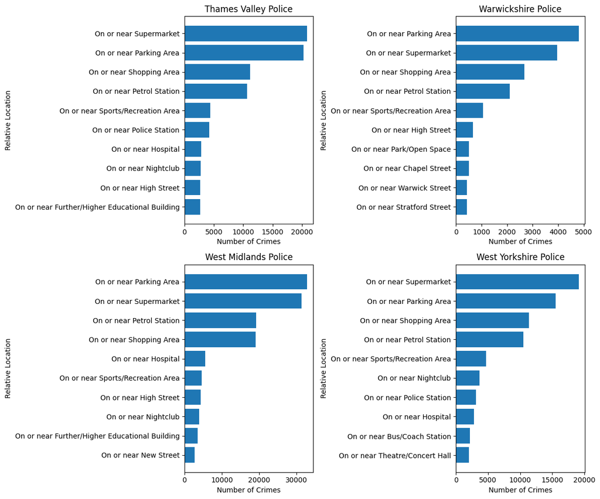

### Figure 2.3: Highest Crime LSOAs by Region

The below facets show the most common LSOAs where crimes are commited for each region. LSOAs are small geographic areas used for statistical analysis in England and Wales. Each LSOA typically contains ~1,500 residents which makes them a good indicator of localised crime per population. While one could infer that these are population centres, this information is not very useful unless placed on a map which leads to the next section.

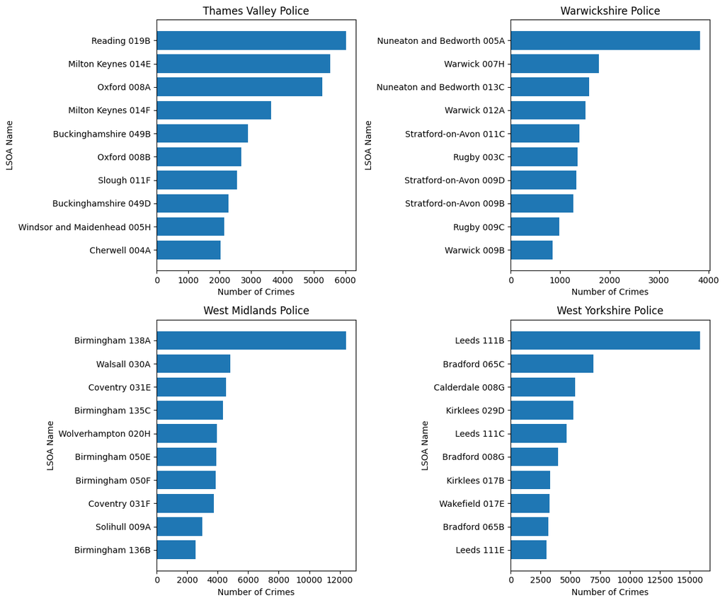

## Section 3: Crime Maps

### Figure 3.1: Highest Crime LSOAs Map

The below map takes the information from the above facet and highlights each LSOA in blue with a tooltip to show crime count. However, this doesn't indicate which areas have low crime.

[interactive chart not shown]

### Figure 3.2: West Midlands LSOAs Crime Map

By using the entire dataset and using the West Midlands Police region as an example, the map below illustrates the crime count of all LSOAs in the region. However, this is difficult to interpret as the LSOAs can be quite small and the large range of values means it is difficult to discern the difference between two lower crime count LSOAs.

[interactive chart not shown]

## Section 4: Time Series Data

### Figure 4.1: Crime Count Over Time (Monthly)

The below chart is a time series graph showing crime counts over time, note that there are some signs of seasonality though this is less pronounced for Thames Valley and Warwickshire.

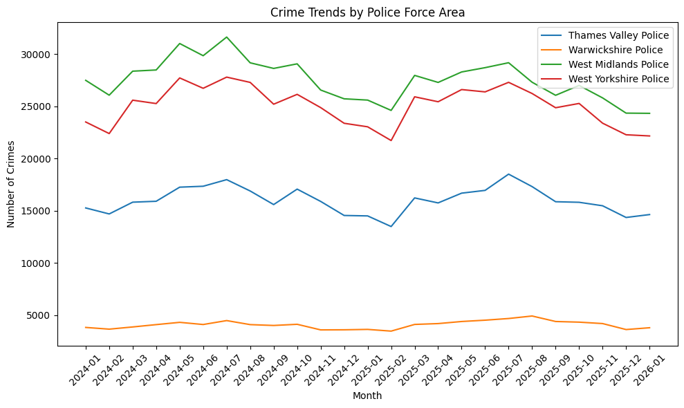

### Figure 4.2: Crime Count Over Time (Smoothed)

The below graph is the smoothed version of the time series data presented above which highlights the seasonality of crime where crime dips to a low during winter around January time and peaks during the summer around July.

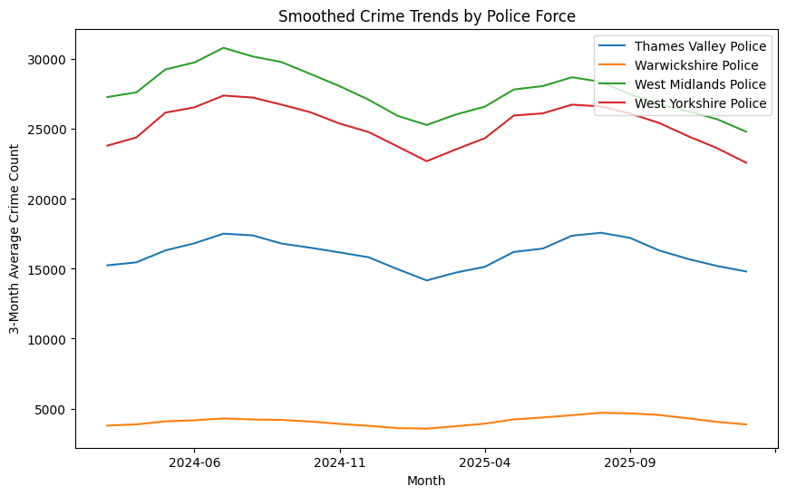

## Conclusions and Next Steps

To conclude, this report provides a very surface level understanding of the information and knowledge available through this dataset and provides a basis for further exploration such as forecasting future crime rate using a techniques such as ARIMA.

In terms of the selection of police forces. This report determines that West Midlands and West Yorkshire are good candidates for further study as their similarities mean that they are easily comparable and differences between them could yield key insights that can be applied to other police regions.

[output not shown]